# Group Assignment. Exploratory Data Analysis

In this data project we will focus on exploratory data analysis of stock prices. Keep in mind, this project is just meant to practice your visualization and pandas skills, it is not meant to be a robust financial analysis or be taken as financial advice.

**NOTE: This project is challenging and you have to look things up on your own to try to solve the tasks issued.**

We'll focus on bank stocks and see how they progressed throughout the [financial crisis](https://en.wikipedia.org/wiki/Financial_crisis_of_2007%E2%80%9308) all the way to early 2017.

## Get the Data

In this section we will learn how to use pandas to directly read data from Google finance using pandas!

First we need to start with the proper imports, which we've already laid out for you here.

*Note: [You'll need to install pandas-datareader for this to work!](https://github.com/pydata/pandas-datareader) Pandas datareader allows you to [read stock information directly from the internet](http://pandas.pydata.org/pandas-docs/stable/remote_data.html) Use these links for install guidance (**pip install pandas-datareader**).*

### The Imports

```python
#!pip install git+https://github.com/pydata/pandas-datareader.git
```

```python
#!pip install pandas-datareader
#!pip install --upgrade pandas
import pandas as pd
import numpy as np
pd.core.common.is_list_like = pd.api.types.is_list_like
from pandas_datareader import data, wb

import datetime
%matplotlib inline
```

## Data

We need to get data using pandas datareader. We will get stock information for the following banks:

- Bank of America
- CitiGroup
- Goldman Sachs
- JPMorgan Chase
- Morgan Stanley
- Wells Fargo

**Figure out how to get the stock data from Jan 1st 2016 to Jan 1st 2017 for each of these banks. Set each bank to be a separate dataframe, with the variable name for that bank being its ticker symbol. This will involve a few steps:**

1. Use datetime to set start and end datetime objects.
2. Figure out the ticker symbol for each bank.
3. Figure out how to use datareader to grab info on the stock.

**Use [this documentation page](https://pandas-datareader.readthedocs.io/en/latest/) for hints and instructions (it should just be a matter of replacing certain values. Use google finance as a source, for example:**

```
# Bank of America
BAC = data.DataReader("BAC", 'google', start, end)
```

```python
start = datetime.datetime(2016, 1, 1)
end = datetime.datetime(2017, 1, 1)
```

```python
# Bank of America
BAC = data.DataReader("BAC", 'iex', start, end)

# CitiGroup
C = data.DataReader("C", 'iex', start, end)

# Goldman Sachs
GS = data.DataReader("GS", 'iex', start, end)

# JPMorgan Chase
JPM = data.DataReader("JPM", 'iex', start, end)

# Morgan Stanley
MS = data.DataReader("MS", 'iex', start, end)

# Wells Fargo
WFC = data.DataReader("WFC", 'iex', start, end)
```

```python
BAC.reset_index(inplace=True)
C.reset_index(inplace=True)
GS.reset_index(inplace=True)
JPM.reset_index(inplace=True)
MS.reset_index(inplace=True)
WFC.reset_index(inplace=True)
```

```python
# Could also do this for a Panel Object
df = data.DataReader(['BAC', 'C', 'GS', 'JPM', 'MS', 'WFC'],'iex', start, end)
```

```python
df.head()
```

| Attributes Symbols date | open BAC | open C | open GS | open JPM | open MS | open WFC | high BAC | high C | high GS | high JPM | ... | close GS | close JPM | close MS | close WFC | volume BAC | volume C | volume GS | volume JPM | volume MS | volume WFC |
| --- | --- | --- | --- | --- | --- | --- | --- | --- | --- | --- | --- | --- | --- | --- | --- | --- | --- | --- | --- | --- | --- |
| 2016-01-04 | 15.5767 | 48.1512 | 167.9451 | 59.2855 | 28.5525 | 48.1621 | 15.6145 | 48.5687 | 169.2827 | 59.3875 | ... | 169.2349 | 58.9796 | 29.2780 | 47.9988 | 114888046 | 23440153 | 3745474 | 25393155 | 15749202 | 25985392 |
| 2016-01-05 | 15.6429 | 48.9007 | 168.8241 | 59.0538 | 29.2780 | 48.0170 | 15.7092 | 48.9672 | 169.5788 | 59.4524 | ... | 166.3210 | 59.0816 | 29.0920 | 47.9807 | 66669974 | 17444931 | 4521610 | 16566703 | 9850456 | 14759616 |
| 2016-01-06 | 15.3305 | 47.5345 | 163.6651 | 58.1453 | 28.4874 | 47.2822 | 15.4252 | 47.9899 | 164.3434 | 58.5207 | ... | 162.2607 | 58.2287 | 28.3665 | 47.0644 | 102760810 | 22501799 | 5539404 | 22961532 | 13057409 | 20026405 |
| 2016-01-07 | 14.8949 | 46.5572 | 159.2321 | 56.9772 | 27.7899 | 46.2752 | 15.0559 | 46.8513 | 161.9358 | 57.4778 | ... | 157.2736 | 55.8740 | 26.9528 | 45.7218 | 116255879 | 37902922 | 5687935 | 27630867 | 18138205 | 30425557 |
| 2016-01-08 | 15.0937 | 46.2346 | 159.3086 | 56.6712 | 27.3528 | 46.0847 | 15.0937 | 46.2441 | 160.9040 | 56.8010 | ... | 156.6240 | 54.6224 | 26.3948 | 44.9598 | 124782383 | 30642964 | 4929788 | 22373287 | 15295619 | 22981395 |

5 rows × 30 columns

##### Add a Column_Company Name (this is filled out for you)

```python
BAC["Company"]='BOA'
C["Company"]='Citi'
GS["Company"]='GoldmanSachs'
JPM["Company"]='JPMorgan'
MS["Company"]='MorganStanley'
WFC["Company"]='WellsFargo'
```

##### Draw the closing prices of BAC

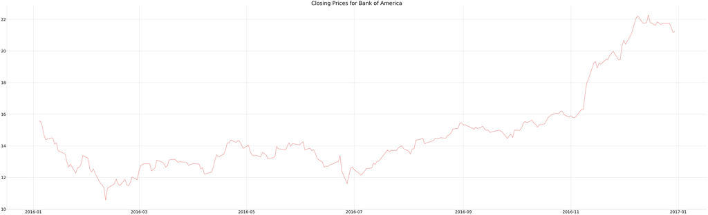

```python
import matplotlib.pyplot as plt

# your code here
# Draw Plot
plt.figure(figsize=(100,30))
plt.plot(pd.to_datetime(BAC.date), BAC.close, color='tab:red')
# Decoration
plt.xticks(fontsize=32)
plt.yticks(fontsize=32)
plt.title("Closing Prices for Bank of America", fontsize=42)
plt.grid(axis='both')

# Remove borders|
plt.gca().spines["top"].set_alpha(0.0)
plt.gca().spines["bottom"].set_alpha(0.3)
plt.gca().spines["right"].set_alpha(0.0)
plt.gca().spines["left"].set_alpha(0.3)
plt.show()
```

##### Append all the data sets

```python
# your code here
banks = pd.concat([BAC, C, GS, JPM, MS, WFC])
```

```python
banks.head()
```

|  | date | open | high | low | close | volume | Company |
| --- | --- | --- | --- | --- | --- | --- | --- |
| 0 | 2016-01-04 | 15.5767 | 15.6145 | 15.3873 | 15.5577 | 114888046 | BOA |
| 1 | 2016-01-05 | 15.6429 | 15.7092 | 15.3683 | 15.5577 | 66669974 | BOA |
| 2 | 2016-01-06 | 15.3305 | 15.4252 | 15.1695 | 15.2263 | 102760810 | BOA |
| 3 | 2016-01-07 | 14.8949 | 15.0559 | 14.6203 | 14.6771 | 116255879 | BOA |
| 4 | 2016-01-08 | 15.0937 | 15.0937 | 14.3551 | 14.3930 | 124782383 | BOA |

##### Derive the average closing price for each bank

```python
# your code here
banks_grouped = banks.groupby("Company")
close_by_company = banks_grouped.close.mean()
close_by_company
```

```
Company
BOA               14.726694
Citi              44.198792
GoldmanSachs     162.903035
JPMorgan          61.577770
MorganStanley     28.166302
WellsFargo        45.174769
Name: close, dtype: float64
```

##### Plot the average closing price for each bank using matplotlib or plotly and cufflinks

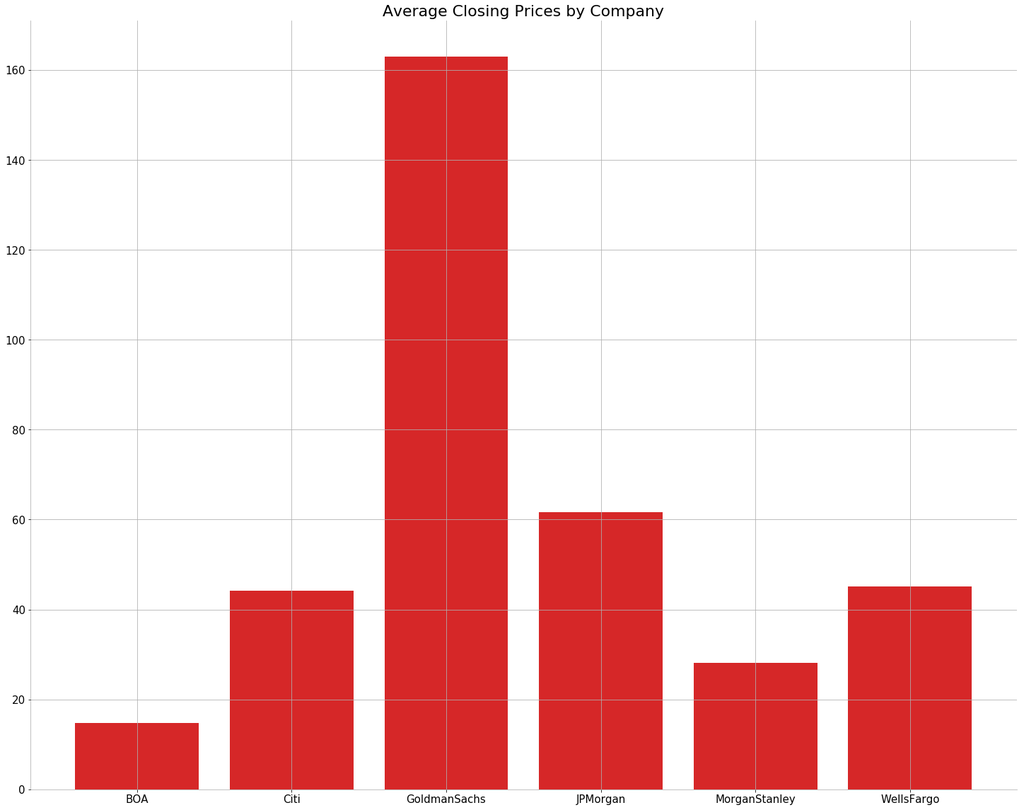

```python
# your code here

# Draw Plot
plt.figure(figsize=(25,20))
plt.bar(close_by_company.index, close_by_company, color='tab:red')

# Decoration
plt.xticks(fontsize=15)
plt.yticks(fontsize=15)
plt.title("Average Closing Prices by Company", fontsize=22)
plt.grid(axis='both')

# Remove borders|
plt.gca().spines["top"].set_alpha(0.0)
plt.gca().spines["bottom"].set_alpha(0.3)
plt.gca().spines["right"].set_alpha(0.0)
plt.gca().spines["left"].set_alpha(0.3)
plt.show()
```

**What is the max Close price for each bank's stock throughout the time period?**

```python
# your code here
max_close_by_company = banks_grouped.close.max()
max_close_by_company
```

```
Company
BOA               22.2744
Citi              58.4981
GoldmanSachs     235.8514
JPMorgan          82.6075
MorganStanley     41.6693
WellsFargo        53.6426
Name: close, dtype: float64
```

**Create a new dataframe called returns. This dataframe will contain the returns for each bank's stock. returns are typically defined by:**

$$r_t = \frac{p_t - p_{t-1}}{p_{t-1}} = \frac{p_t}{p_{t-1}} - 1$$

**We can use pandas pct_change() method on the Close column to create a new dataframe representing this return value. Use .groupby().**

```python
# your code here
banks_list = [BAC, C, GS, JPM, MS, WFC]
for b in banks_list:
    b["returns"] = b.close.pct_change(periods=1)
banks_new = pd.concat([BAC, C, GS, JPM, MS, WFC])
```

**Using this returns DataFrame, figure out on what dates each bank stock had the best and worst single day returns. Did anything significant happen that day?**

```python
# your code here
banks_grouped = banks_new.groupby("Company")
min_returns_by_company = banks_grouped.returns.min()
max_returns_by_company = banks_grouped.returns.max()
```

```python
min_returns_by_company
```

```
Company
BOA             -0.074074
Citi            -0.093567
GoldmanSachs    -0.070745
JPMorgan        -0.069476
MorganStanley   -0.101503
WellsFargo      -0.045919
Name: returns, dtype: float64
```

```python
max_returns_by_company
```

```
Company
BOA              0.070793
Citi             0.073185
GoldmanSachs     0.058872
JPMorgan         0.083286
MorganStanley    0.070966
WellsFargo       0.075850
Name: returns, dtype: float64
```

```python
for name in min_returns_by_company.index:
    returns_value = min_returns_by_company[name]
    date = list(banks_new[(banks_new.Company == name) & (banks_new.returns == returns_value)].date)[0]
    print("Min returns for {} happened on {} with return of {}".format(name, date, np.round(returns_value, 3)))
```

```
Min returns for BOA happened on 2016-06-24 with return of -0.074
Min returns for Citi happened on 2016-06-24 with return of -0.094
Min returns for GoldmanSachs happened on 2016-06-24 with return of -0.071
Min returns for JPMorgan happened on 2016-06-24 with return of -0.069
Min returns for MorganStanley happened on 2016-06-24 with return of -0.102
Min returns for WellsFargo happened on 2016-06-24 with return of -0.046
```

```python
for name in max_returns_by_company.index:
    returns_value = max_returns_by_company[name]
    date = list(banks_new[(banks_new.Company == name) & (banks_new.returns == returns_value)].date)[0]
    print("Max returns for {} happened on {} with return of {}".format(name, date, np.round(returns_value, 3)))
```

```
Max returns for BOA happened on 2016-02-12 with return of 0.071
Max returns for Citi happened on 2016-02-12 with return of 0.073
Max returns for GoldmanSachs happened on 2016-11-09 with return of 0.059
Max returns for JPMorgan happened on 2016-02-12 with return of 0.083
Max returns for MorganStanley happened on 2016-11-09 with return of 0.071
Max returns for WellsFargo happened on 2016-11-10 with return of 0.076
```

**Please state here what you have noticed. Did anything significant happen in that time frame?**

It seems like the minimum returns all happened on June 24th, 2016.

That is the date British Prime Minister David Cameron resigns after the **UK votes to leave the EU!**

The maximum returns happened on Feb. 12th, 2016 (BOA, Citi, JPMorgan) and Nov. 9th/10th, 2016 (GoldmanSachs, MorganStanley, WellsFargo). Based on our research, during the time of 2016-02-12, the stock market should be sinking instead of blooming. Our theory is the economic was simply recovering. On the date of 2016-11-09, which is the United States presidential election and general elections day, the banks generated the highest return.

**Take a look at the standard deviation of the returns, which stock would you classify as the riskiest over the entire time period?**

```python
#  your code here
banks_new.groupby("Company").returns.std()
```

```
Company
BOA              0.020255
Citi             0.020049
GoldmanSachs     0.016906
JPMorgan         0.015439
MorganStanley    0.020555
WellsFargo       0.014910
Name: returns, dtype: float64
```

**Which would you classify as the riskiest for the year 2016?**

```python
max_std = banks_new.groupby("Company").returns.std().max()
print("The riskiest stock for the year 2016 belongs to MorganStanley with standard deviation of {}".format(max_std))
```

```
The riskiest stock for the year 2016 belongs to MorganStanley with standard deviation of 0.02055459295294861
```

**Create a density plot using any library you like to visualize the previous year's return for each bank**

```python
import seaborn as sns
```

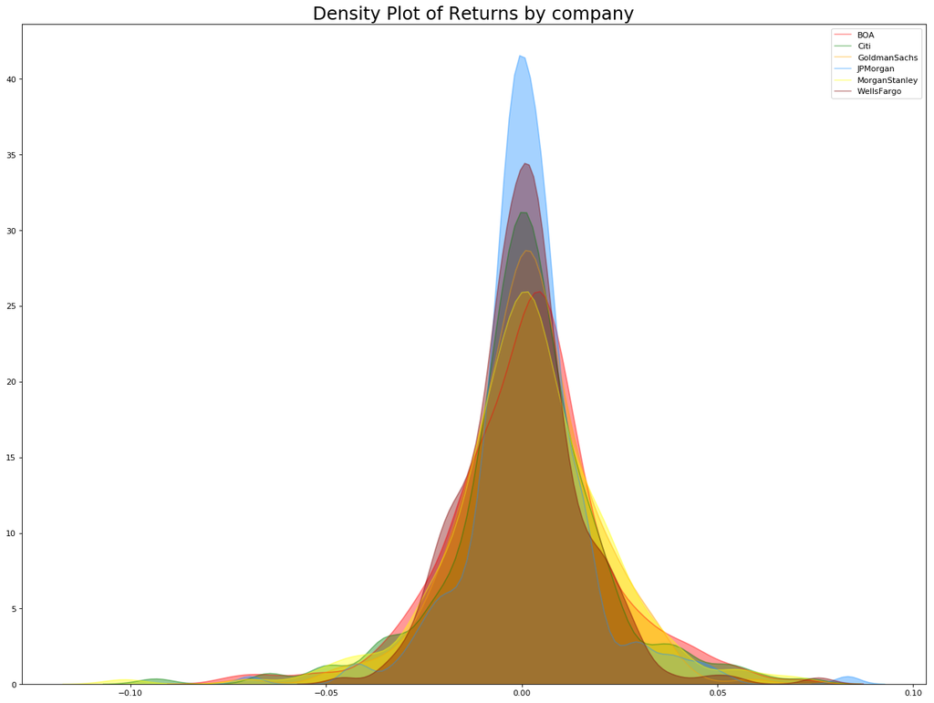

```python
# your code here
plt.figure(figsize=(20,15), dpi= 80)
sns.kdeplot(banks_new[banks_new.Company == "BOA"].returns, shade=True, color="red", label="BOA", alpha=.4)
sns.kdeplot(banks_new[banks_new.Company == "Citi"].returns, shade=True, color="green", label="Citi", alpha=.4)
sns.kdeplot(banks_new[banks_new.Company == "GoldmanSachs"].returns, shade=True, color="orange", label="GoldmanSachs", alpha=.4)
sns.kdeplot(banks_new[banks_new.Company == "JPMorgan"].returns, shade=True, color="dodgerblue", label="JPMorgan", alpha=.4)
sns.kdeplot(banks_new[banks_new.Company == "MorganStanley"].returns, shade=True, color="yellow", label="MorganStanley", alpha=.4)
sns.kdeplot(banks_new[banks_new.Company == "WellsFargo"].returns, shade=True, color="maroon", label="WellsFargo", alpha=.4)

# Decoration
plt.title('Density Plot of Returns by company', fontsize=22)
plt.legend()
plt.show()
```

### Moving Averages

**Please derive the moving averages for these stocks in the year 2016. Use .rolling() in pandas to get the rolling average calculation.**

```python
# your code here
# your code here
banks_list = [BAC, C, GS, JPM, MS, WFC]
for b in banks_list:
    b["moving_avg"] = b.close.rolling(window=30).mean()
banks_new = pd.concat([BAC, C, GS, JPM, MS, WFC])
```

**Plot the rolling 30 day average against the Close Price for Bank Of America's stock for the year 2016**

[figure not shown]

```python
# your code here
plt.figure(figsize=(20,15), dpi= 80)
sns.lineplot(data=banks_new[banks_new.Company == "BOA"].moving_avg, color="red", label="BOA", alpha=.4)
# Decoration
plt.title('Moving Average by Company', fontsize=22)
plt.legend()
plt.show()
```

**Create a heatmap of the correlation between the stocks Close Price.**

```python
nd = {'BAC': BAC['close'],
    'C': C['close'],
    'GS': GS['close'],
    'JPM': JPM['close'],
    'MS': MS['close'],
    'WFC':WFC['close']}
ndf = pd.DataFrame(data=nd)
```

```python
ndf.head()
```

|  | BAC | C | GS | JPM | MS | WFC |
| --- | --- | --- | --- | --- | --- | --- |
| 0 | 15.5577 | 48.5117 | 169.2349 | 58.9796 | 29.2780 | 47.9988 |
| 1 | 15.5577 | 48.2556 | 166.3210 | 59.0816 | 29.0920 | 47.9807 |
| 2 | 15.2263 | 47.5535 | 162.2607 | 58.2287 | 28.3665 | 47.0644 |
| 3 | 14.6771 | 45.1245 | 157.2736 | 55.8740 | 26.9528 | 45.7218 |
| 4 | 14.3930 | 43.7678 | 156.6240 | 54.6224 | 26.3948 | 44.9598 |

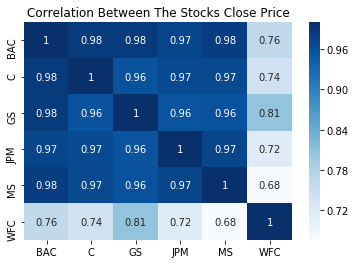

```python
corr = ndf.corr()
sns.heatmap(corr, annot=True, cmap="Blues")
plt.title('Correlation Between The Stocks Close Price')
```